# Exercise Markup Languages Week 2

Jan-Willem Simons

13/10/2020

# Defining the task

The randomly generated task of interest is that of comparing the graph features of a social network simulated under a social network model to the same graph features from an empirical social network. The three model candidates are the Erdős–Rényi, Barabási-Albert and Watts-Strogatz models, each of which have historically been used to describe and understand real-world social network structures. As we will see some graph features can indeed be captured by these models. Generally speakin ghowever, these models are not able to provide a valid description of real-world social networks. Even so, from the tradition of these models social network researchers ultimately transitioned to other models which are better able to capture the structure of real-world social networks, such as exponential random graph models (ERGMs) and stochastic actor-oriented models (SAOMs).

# Packages and data preparation

```r
### If necessary, install and require "networkdata" and "igraph" packages.
## Evaluate whether packages "networkdata" and "igraph" need to be installed.
if(!require(networkdata)) install.packages("networkdata")
if(!require(igraph)) install.packages("igraph")
# If the "networkdata" package is not available for your R-version, please use:
# remotes::install_github("schochastics/networkdata")
## Pullling packages "networkdata" and "igraph" from library.
library(networkdata)
library(igraph)
```

```r
### Data preparation.
## Store "igraph" network object.
net <- networkdata::highschool_boys
## Symmetrize the network (necessary for computations).
net.symm <- as.undirected(graph = net, mode = 'collapse')

### Define a function which provides a description of some graph features of interest.
## Defining the function.
describe <- function(g) { # Function with as its input a graph "g";
  return(c(density = edge_density(g), # calculate density;
           transitivity = transitivity(g,type='global'),  # calculate transitivity;
           deg.variance = var(degree(g)), # calculate degree variance;
           av.geo.dist = mean_distance(g,unconnected=FALSE))) # calculate average geodesic distance.
}
## Run "describe" function for description of empirical graph features.
describe(net.symm)
```

```
##      density transitivity deg.variance  av.geo.dist
##     0.115528     0.404302    12.173085     2.639337
```

# Network simulation

Here I generate a list of 1000 undirected Bernoulli graphs which have the same size as the empirical network. I specify the tie probability to be equal to the observed density of the empirical network.

```r
### Generating a list of 1000 undirected Erdős–Rényi graphs with size equal to empirical
### network and empirical network density as Bernoulli distributed probability for forming
### a tie.
## Store number of vertices in object "size".
size <- vcount(net.symm)
## Store empirical density in object "dens'.
dens <- edge_density(net.symm)
## Draw 1000 random undirected Erdős–Rényi graphs.
bernoulli1000 <- lapply(1 : 1000, function(i){
  erdos.renyi.game(n = size, p.or.m = dens, directed = FALSE)
  })
```

Here I generate another list of 1000 undirected networks with a Barabási-Albert model such that the average density matches the observed density. Here the networks are also of the same size as the empirical network.

```r
### Generating a list of 1000 undirected Barabási-Albert graphs with size and mean density equal to empirical
### network.
## Sum over rows of empirical adjacency matrix.We need to observe that vertices enter one after the other in this
## model. We therefore calculate this sequence, where we make sure that we only count ties that are added to
## nodes that already have entered before.
sequence <- rowSums(as_adjacency_matrix(net.symm, type = "lower", sparse = FALSE))
## Apply barabasi.game() function 1000 times and store resulting scale-free graphs in a list.
scalefree1000 <- lapply(1 : 1000, function(i){
  barabasi.game(n = size, out.seq = sequence, directed = FALSE)
  })
```

Here I generate a third list of 1000 undirected networks with a Watts-Strogatz model such that again the average density matches the observed density, but also so that the average clustering (transitivity) matches the observed clustering (transitivity). Again, the networks are of the same size as above.

```r
### Generating a list of 1000 undirected Watts-Strogatz graphs with size equal to empirical network and mean density
### and transitivity close to equal to empirical network.
## Function that modifies the sample_smallworld function of the igraph package such as to generate a graph with
## desired numbers of nodes and edges by "thinning".
my_small_world <- function(n,e,p) {
  half.degree <- ceiling(e / n)
  net <- sample_smallworld(dim = 1, size = size, nei = half.degree, p = p)
  net <- delete_edges(net, sample(E(net), ecount(net) - e))
  return(net)
}
## Empirical parameters to calibrate to:
# Empirical number of edges.
nr.edges <- ecount(net.symm)
# Empirical number of vertices.
size <- vcount(net.symm)
# Empirical transitivity.
trans <- transitivity(net.symm)
## Define function for which the zero defines the rewiring parameter that gives empirical transitivity:
mean.trans.smallworld <- function(p) {
  mean(sapply(1 : 1000, function(i){
    return(transitivity(my_small_world(n = size, e = nr.edges, p = p)))})) - trans}
## Find this parameter (takes a while):
p.for.transitivity <- uniroot(mean.trans.smallworld, lower = 0, upper = 1)
## Generate the desired sample of networks:
smallworld1000 <- lapply(1 : 1000, function(i){
  net <- my_small_world(n = size, e = nr.edges, p = p.for.transitivity)
})
```

# Visualization

By way of example I visualise the first of each of the three generated network lists, and the empirical data set.

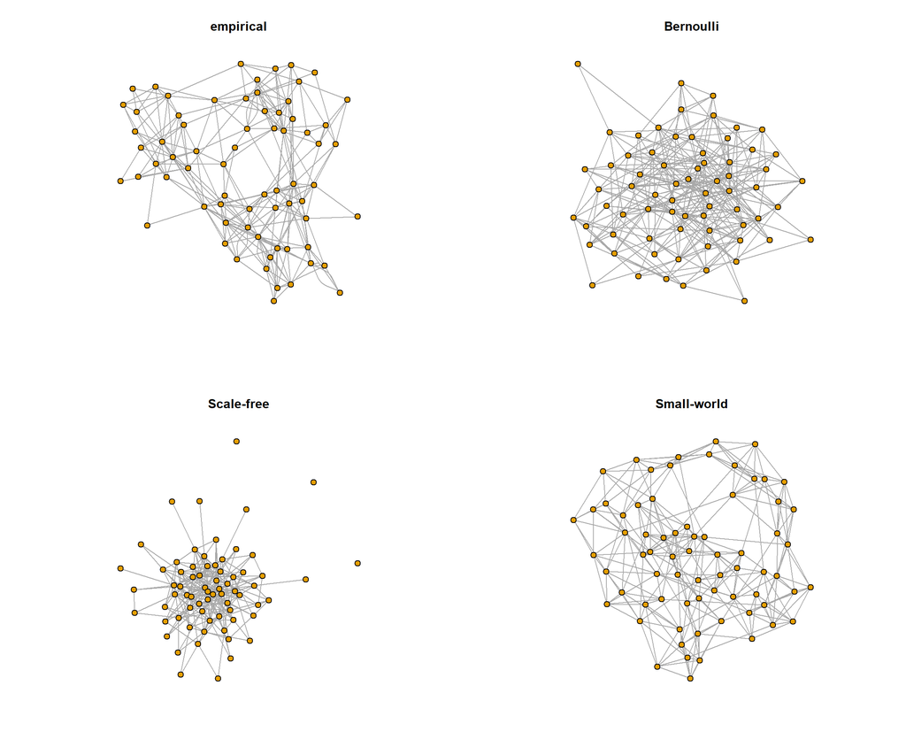

```r
### Plotting the first of each of the three generated network lists and the empirical data set.
par(mfrow=c(2, 2))
plot(net.symm,vertex.size=5,vertex.label=NA,main='empirical')
plot(bernoulli1000[[1]],vertex.size=5,vertex.label=NA,main='Bernoulli')
plot(scalefree1000[[1]],vertex.size=5,vertex.label=NA,main='Scale-free')
plot(smallworld1000[[1]],vertex.size=5,vertex.label=NA,main='Small-world')
```

# Network comparison

I now make comparative plots of the distributions of the three indices transitivity, degree variance, and average geodesic distance in the three network lists by plotting them.

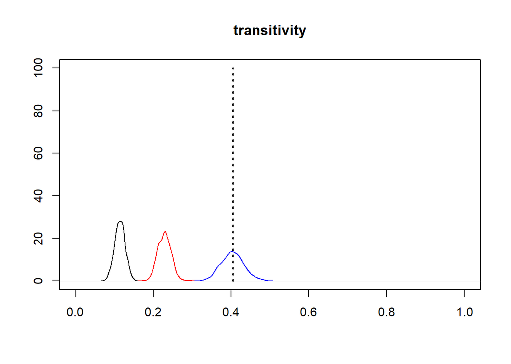

```r
# Get index distributions
index.bernoulli <- sapply(bernoulli1000,describe)
index.scalefree <- sapply(scalefree1000,describe)
index.smallworld <- sapply(smallworld1000,describe)

# Transitivity
plot(density(index.bernoulli[2,]),xlim=c(0,1),ylim=c(0,100), main="transitivity",xlab=NA,ylab=NA)
lines(density(index.scalefree[2,]),col="red")
lines(density(index.smallworld[2,]),col="blue")
lines(rep(describe(net.symm)[2],2),c(0,100),lwd=2,lty=3)
```

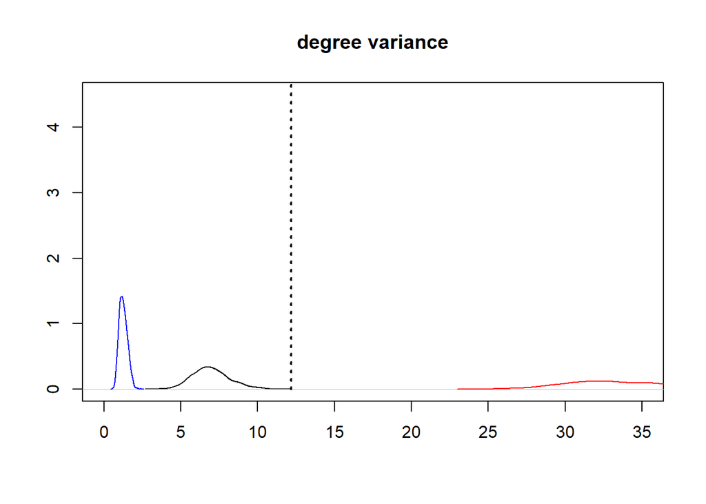

```r
# Degree variance
plot(density(index.bernoulli[3,]),xlim=c(0,35),ylim=c(0,4.5), main="degree variance",xlab=NA,ylab=NA)
lines(density(index.scalefree[3,]),col="red")
lines(density(index.smallworld[3,]),col="blue")
lines(rep(describe(net.symm)[3],2),c(0,100),lwd=2,lty=3)
```

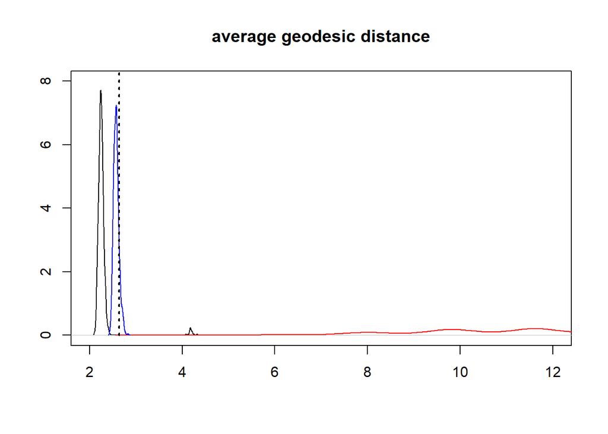

```r
# Average geodesic distance
plot(density(index.bernoulli[4,]),xlim=c(2,12),ylim=c(0,8), main="average geodesic distance",xlab=NA,ylab=NA)
lines(density(index.scalefree[4,]),col="red")
lines(density(index.smallworld[4,]),col="blue")
lines(rep(describe(net.symm)[4],2),c(0,100),lwd=2,lty=3)
```

# Some notes on what this means

We can see that the empirical position of the transitivity and average geodesic distance properties of the empirical network are located in the density distribution of the Watts-Strogatz model. For the degree variance this empirical value is situated in the density distribution of the Erdős–Rényi random graph model. This tells us that the Barabási-Albert scale-free graphs do not seem to capture the structural properties of the empirical network at all, whereas the Erdős–Rényi random graphs capture at least the degree variance property, and the Watts-Strogatz small world graphs capture both the transitivity and average characteristic path length properties but not the degree variance property.

It is not surprising that the small-world network provides the best description of the empirical network, because it explicitly tries to strike a balance between clustering and characteristic path length (which is an important property of empirical networks), whereas the other two do not (random tie formation in the first, preferential attachment in the second). It is somewhat surprising that the degree variance is best captured by the Erdős–Rényi random graph, with the variance in degree being very low in the Watts-Strogatz small world graphs and much too high in the Barabási-Albert scale-free graphs. It makes sense that the variance will be high in the Barabási-Albert graphs, due to the preferential attachment mechanism some nodes will have many ties and most only a few to none. Upon thinking on it it also makes sense that the degree variance is low in the Watt-Strogatz small world graph, because most vertices are clustered with only a few having linking ties to other clusters. The degree variance of the empirical network lies somewhere in between these two, which apparantly is best captured by the Erdős–Rényi random graph, i.e., by Bernoulli distributed randomness.